# Study on Economic Conditions Across Different Income Regions

## Introduction

### Purpose of this Project:

- This project is designed to visualize the effects of the Economic Status of a State on the Life and Death of its Residents from year 2000 to year 2012
- Primarily, the Average Life Expectancy and the GDP per Capita of both Sex are compared to show the conditions of Countries in comparison with each other.

## How does the world look?

## Aggregated on Average

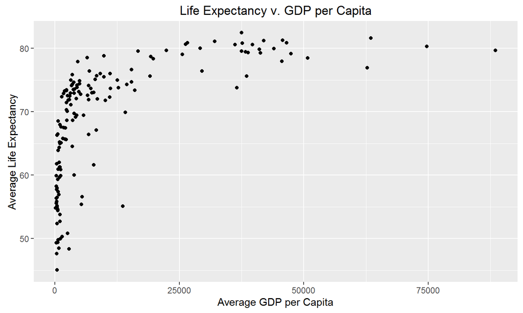

- There is an apparent correlation between the Life Expectancy and the GDP per Capita

## Highlighted on Region

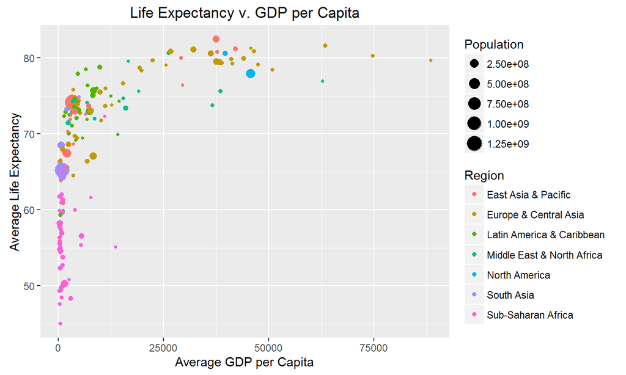

## Log GDP per Capita

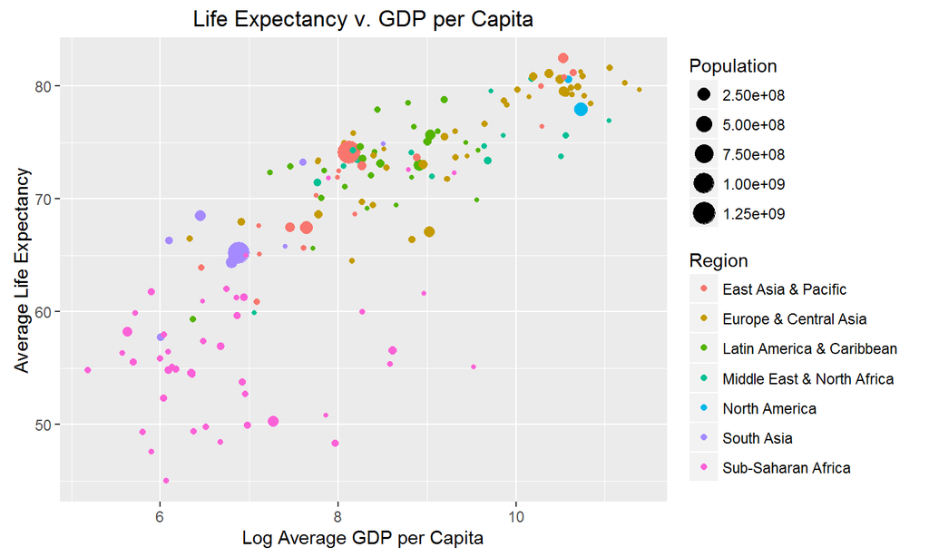

## Highlighted on Income Groups

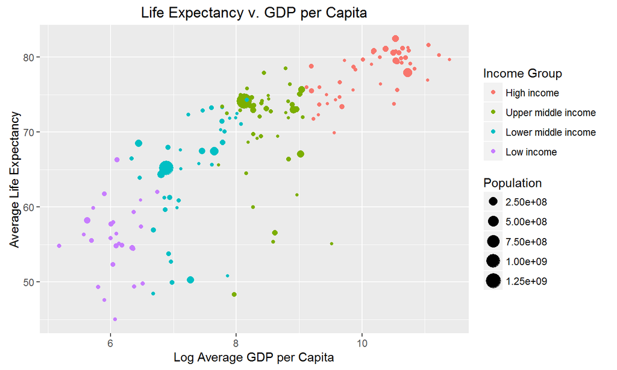

## How do Income Gaps Differ?

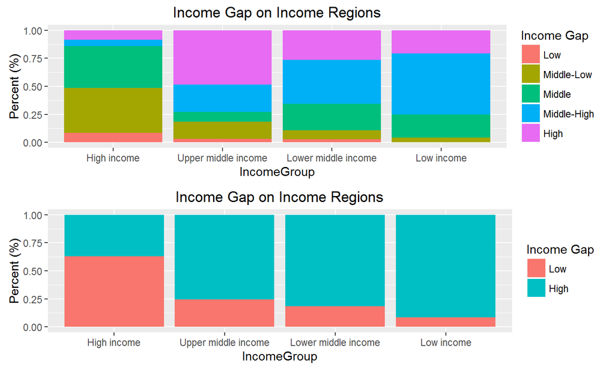

## How do Causes of Mortality Differ?

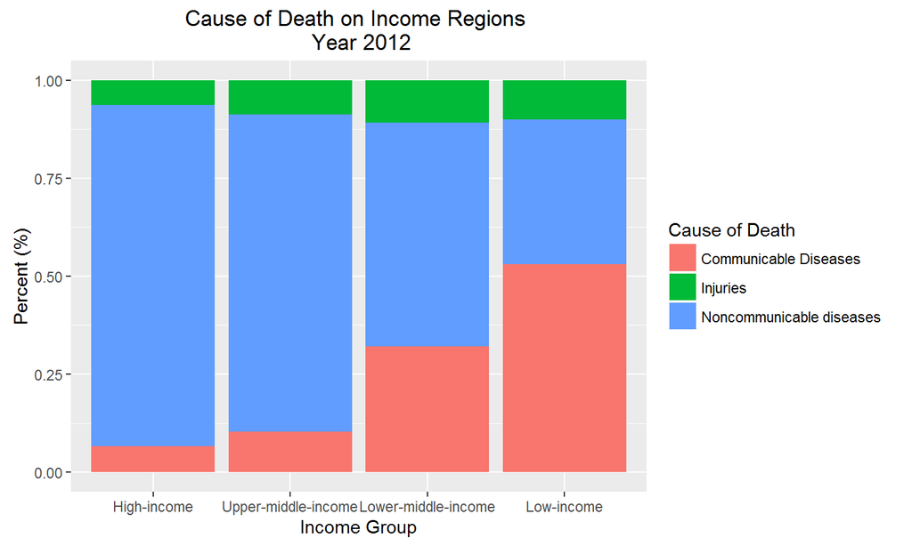

## Cause of Mortality 2012 v. 2000

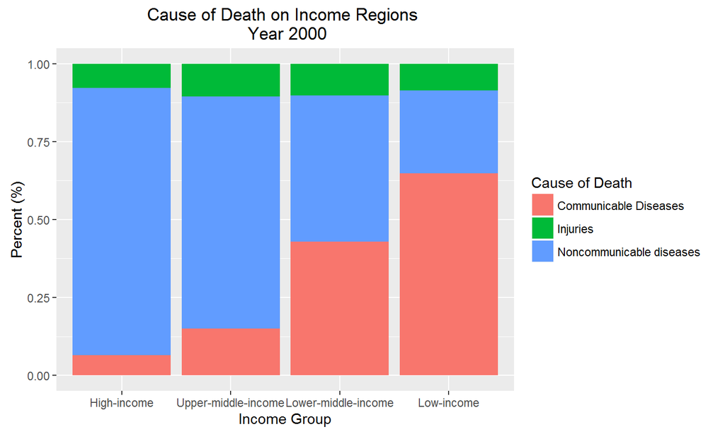

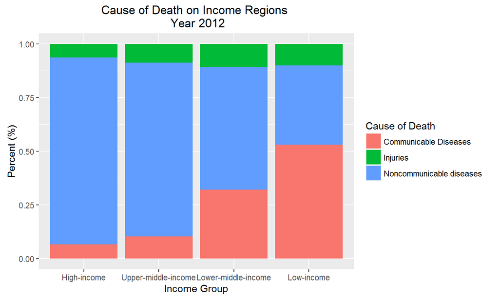

## Healthier People, More Money Earned

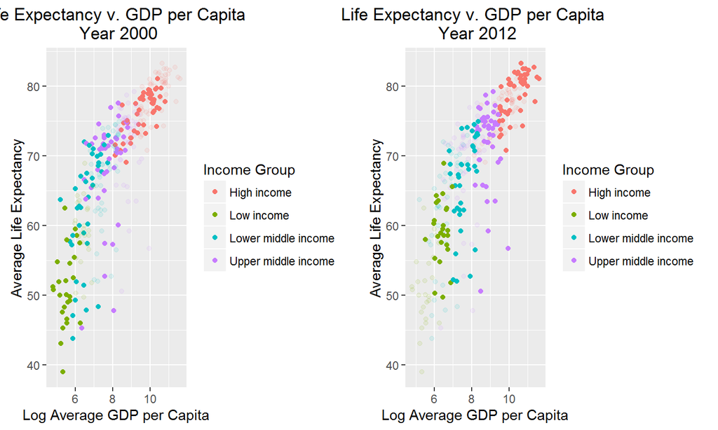

- Medical Advances allowed people to live longer  
- Longer Life Expectancy meant people are more willing to  
invest in human capital (knowledge + experience)

## Change within Income Groups

## Low Income 2000

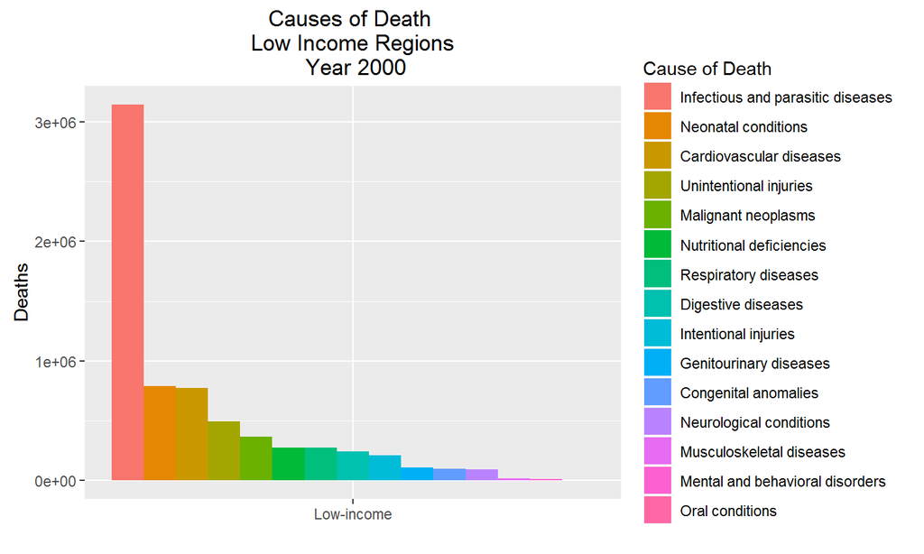

## Low Income 2012

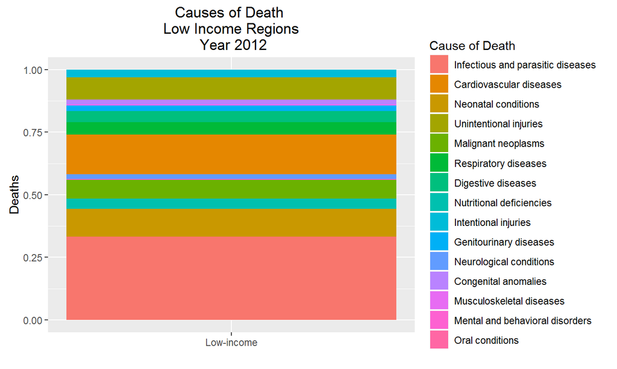

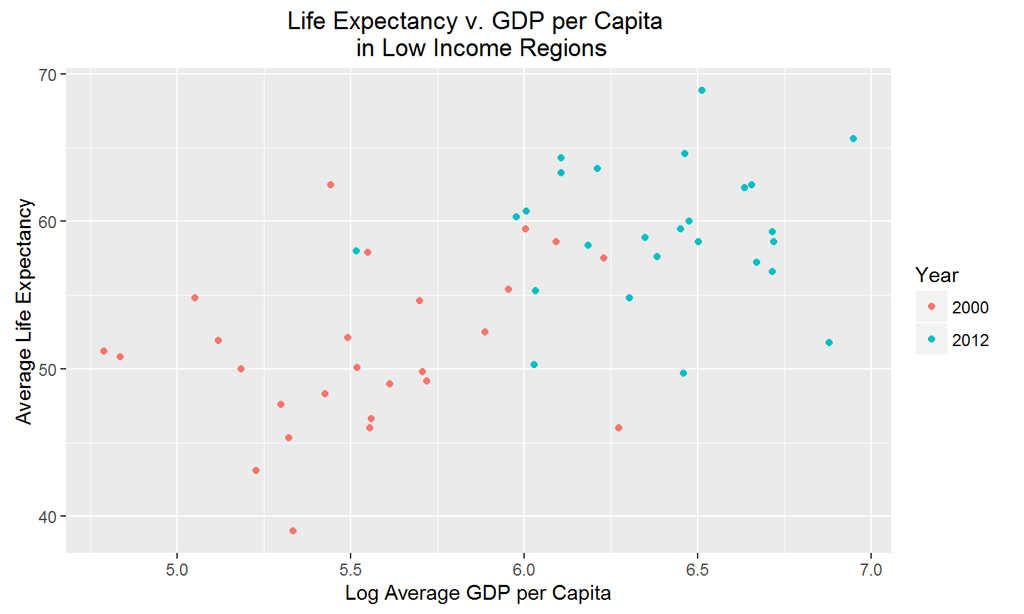

## Lower-Middle Income 2000

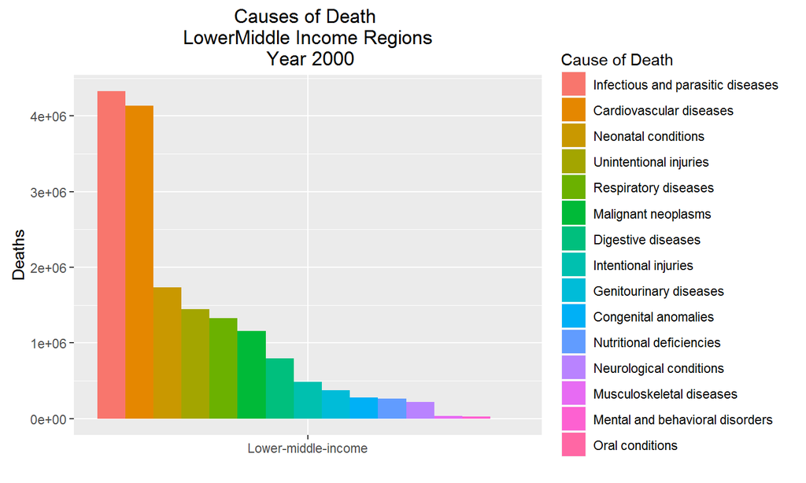

## Lower-Middle Income 2012

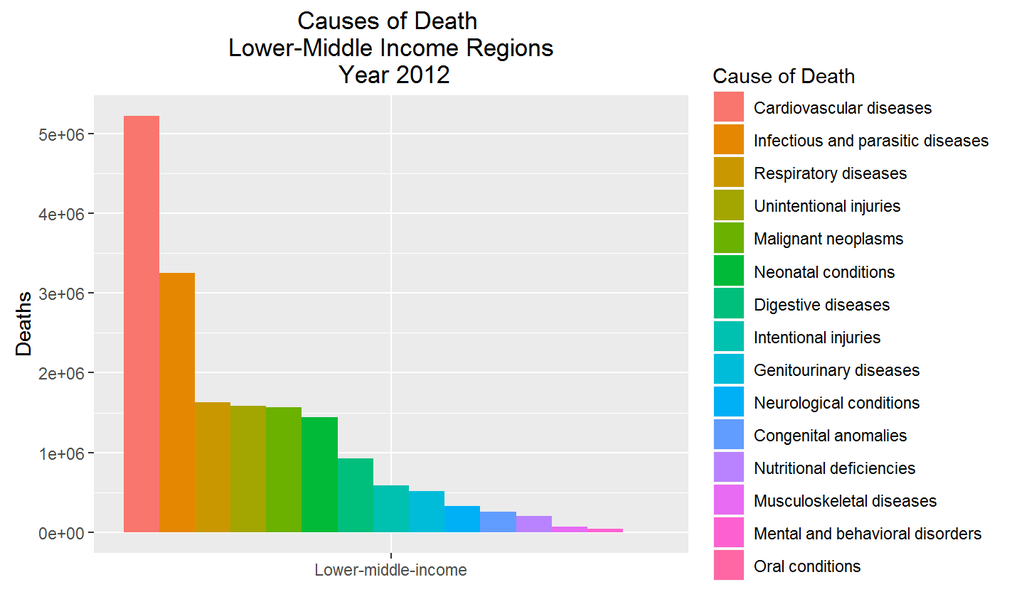

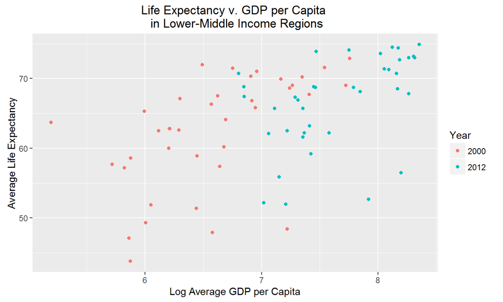

## Upper-Middle Income 2000

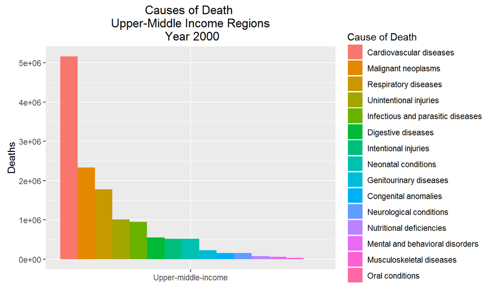

## Upper-Middle Income 2012

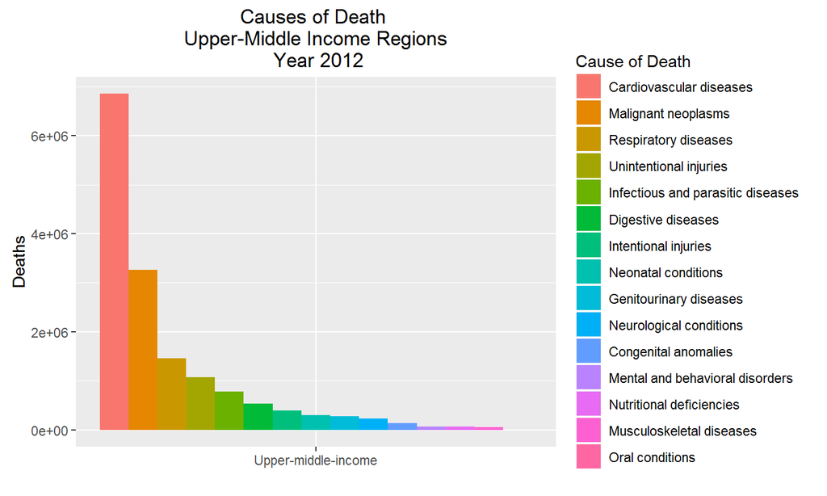

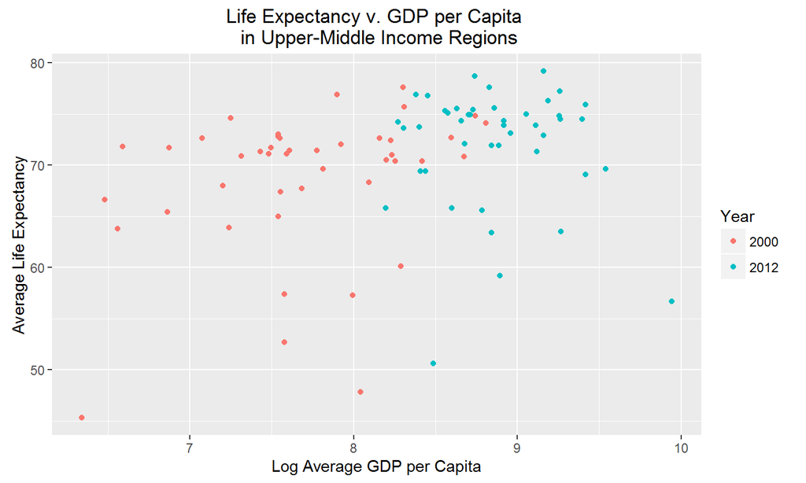

## Upper Income 2000

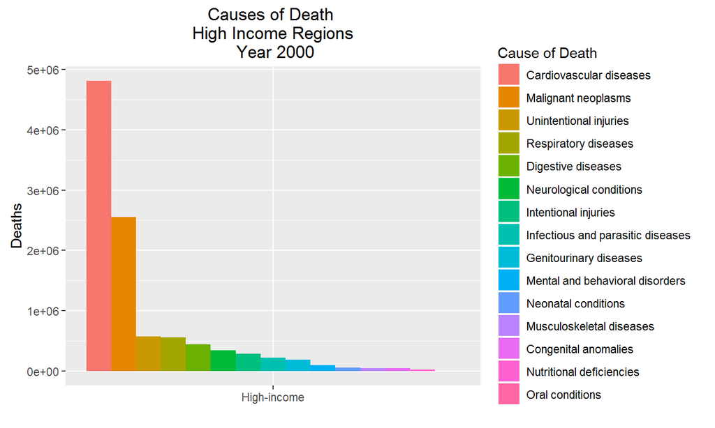

## Upper Income 2012

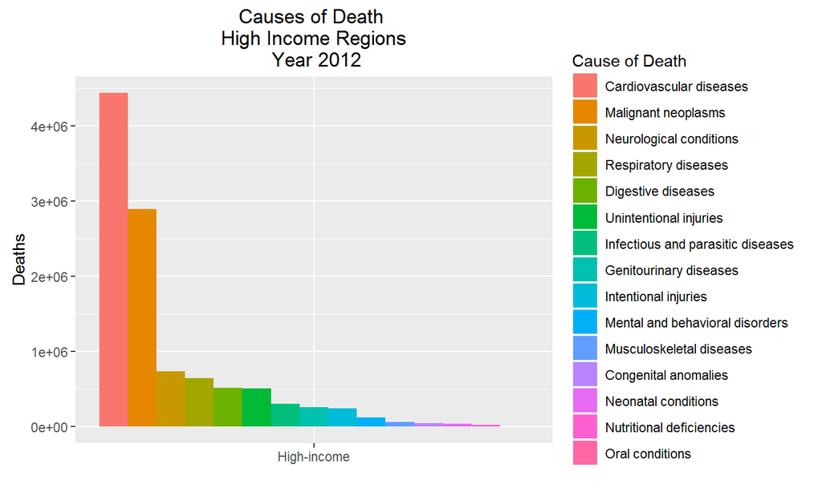

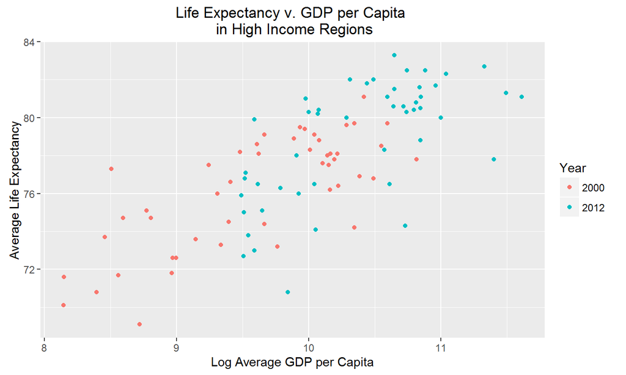

## Next Steps

- Increase the range of time in years
- Analyze mortality rate on different age groups
- Analyze Economic Conditions by Sex
- Analyze Economic Conditions by Population Density (City, Rural Areas)
- Big Mac Index